# Anoop Model Scripts

## 2.2 Logistic Regression - Predicting for training data using the model fitted with these variables

```r
pred_train <- predict(fit_logit, df.train[,-1], type = "response")
pred_train <- ifelse(pred_train > 0.5, 1, 0)
ct <- table(df.train[,1], pred_train)
ct
```

```
##    pred_train
##      0  1
##   0 85  6
##   1 26 15
```

```r
accu <- (ct[1,1] + ct[2,2])/(ct[1,2]+ ct[2,1]+ ct[1,1] + ct[2,2])
accu
```

```
## [1] 0.7575758
```

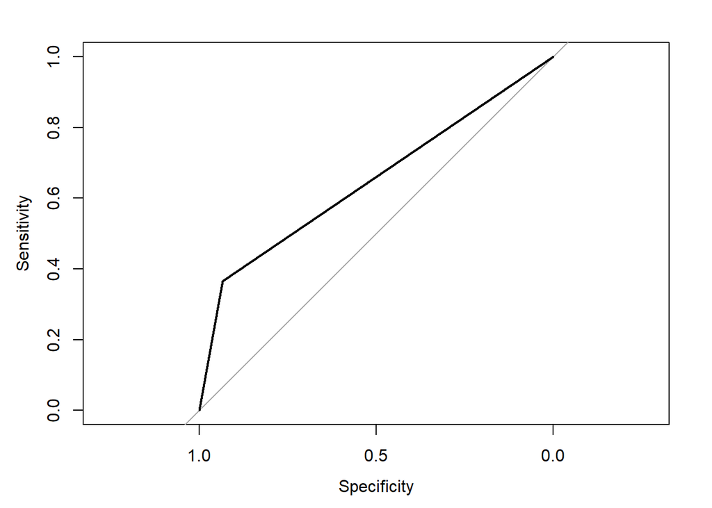

```r
roccurve <- roc(df.train$Outcome ~ pred_train)
plot(roccurve)
```

```r
auc(roccurve)
```

```
## Area under the curve: 0.65
```

```r
precision <- ct[1,1]/(ct[1,1] + ct[1,2])
precision
```

```
## [1] 0.9340659
```

```r
recall <- ct[1,1]/(ct[1,1] + ct[2,1])
recall
```

```
## [1] 0.7657658
```

```r
f1score <- (2*precision*recall)/(precision+recall)
f1score
```

```
## [1] 0.8415842
```

## 2.3 Logistic Regression - Predicting for Validation data using the fitted model

```r
pred_valid <- predict(fit_logit, df.valid[,-1], type = "response")
pred_valid <- ifelse(pred_valid > 0.5, 1, 0)
ct <- table(df.valid[,1], pred_valid)
ct
```

```
##    pred_valid
##      0  1
##   0 28  3
##   1 10  4
```

```r
accu <- (ct[1,1] + ct[2,2])/(ct[1,2]+ ct[2,1]+ ct[1,1] + ct[2,2])
accu
```

```
## [1] 0.7111111
```

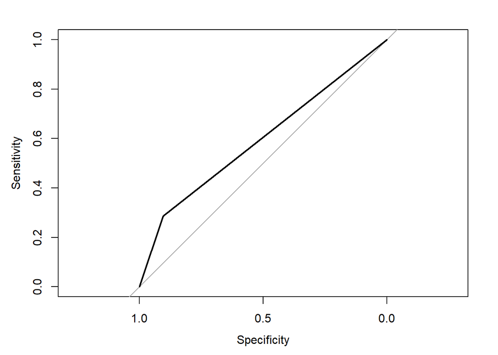

```r
roccurve <- roc(df.valid$Outcome ~ pred_valid)
plot(roccurve)
```

```r
auc(roccurve)
```

```
## Area under the curve: 0.5945
```

```r
precision <- ct[1,1]/(ct[1,1] + ct[1,2])
recall <- ct[1,1]/(ct[1,1] + ct[2,1])
f1score <- (2*precision*recall)/(precision+recall)
f1score
```

```
## [1] 0.8115942
```

## 2.4 Logistic Regression - Predicting on Test data using the fitted model

```r
pred_test <- predict(fit_logit, df.testfinal[,-1], type = "response")
pred_test <- ifelse(pred_test > 0.5, 1, 0)
ct <- table(df.testfinal[,1], pred_test)
ct
```

```
##    pred_test
##     0 1
##   0 8 0
##   1 2 2
```

```r
accu <- (ct[1,1] + ct[2,2])/(ct[1,2]+ ct[2,1]+ ct[1,1] + ct[2,2])
accu
```

```
## [1] 0.8333333
```

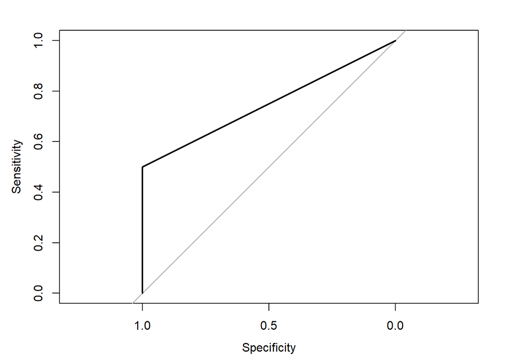

```r
roccurve <- roc(df.testfinal$Outcome ~ pred_test)
plot(roccurve)
```

```r
auc(roccurve)
```

```
## Area under the curve: 0.75
```

```r
precision <- ct[1,1]/(ct[1,1] + ct[1,2])
precision
```

```
## [1] 1
```

```r
recall <- ct[1,1]/(ct[1,1] + ct[2,1])
recall
```

```
## [1] 0.8
```

```r
f1score <- (2*precision*recall)/(precision+recall)
f1score
```

```
## [1] 0.8888889
```

We observe an accuracy of 83.33% for this model on the test dataset. We observe that the area under the receiver operating characteristics curve is 0.75

# 3 Random Forest Model

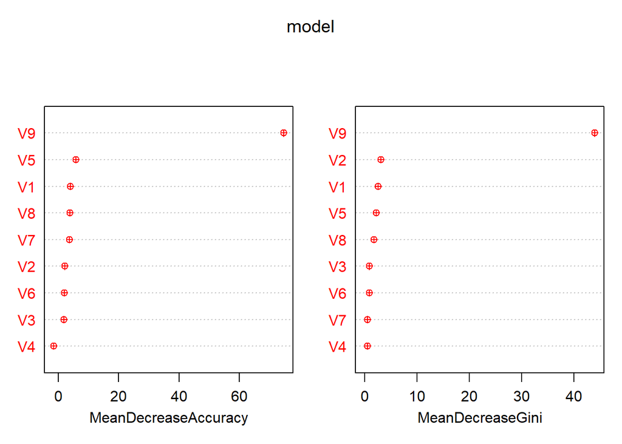

```r
require(randomForest)
model <- randomForest(Outcome ~ V1+V2+V3+V4+V5+V6+V7+V8+V9, data = df.train, importance = TRUE)
varImpPlot(model, col = 'red', pch = 10)
```

## Fitting full model Here we can see that the most important variable is V9. But from our EDA and logistic model’s results we can conclude that V9 should be removed from the model.

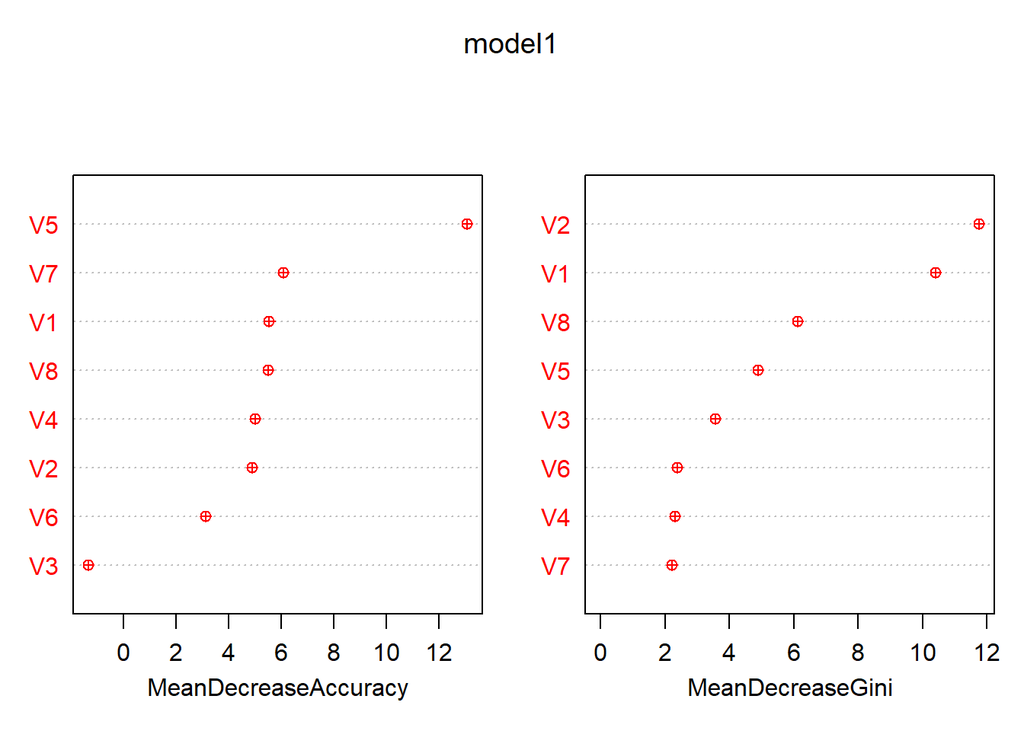

```r
model1 <- randomForest(Outcome ~ V1+V2+V3+V4+V5+V6+V7+V8, data = df.train, importance = TRUE)
varImpPlot(model1, col = 'red', pch = 10)
```

## 3.1 Hyperparameter tuning

We will now perform hyperparameter tuning for number of trees and mtries to improve the results for the model

```r
a=c()
for (i in 2:8) {
  model3 <- randomForest(Outcome ~ V1+V2+V3+V4+V5+V6+V7+V8, data = df.train, ntree = 500, mtry = i, importance = TRUE)
  predTrain <- predict(model3, df.train, type = "class")
  a[i-1] = mean(predTrain == df.train$Outcome)
}
a
```

```
## [1] 0.9242424 0.9924242 0.9924242 1.0000000 1.0000000 1.0000000 1.0000000
```

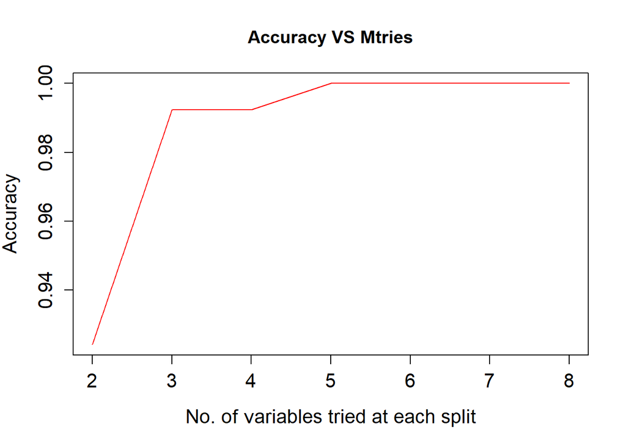

```r
plot(2:8,a,type = 'l', col = 'red', xlab = 'No. of variables tried at each split',
     ylab = 'Accuracy', cex.lab = 1.3, cex.axis = 1.3, main = 'Accuracy VS Mtries')
```

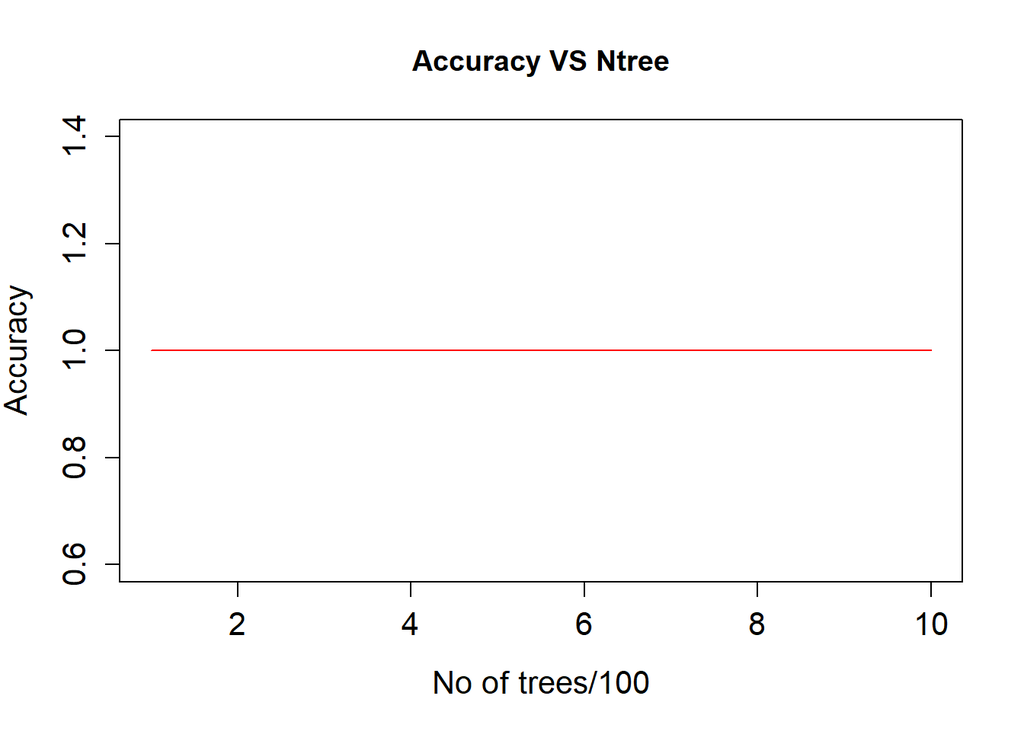

```r
b = c()
for (i in seq(100,1000,100)) {
  model4 <- randomForest(Outcome ~ V1+V2+V3+V4+V5+V6+V7+V8, data = df.train, ntree = i, mtry = 5, importance = TRUE)
  predTrain <- predict(model4, df.train, type = "class")
  b[i] = mean(predTrain == df.train$Outcome)
}
b <- b[!is.na(b)]

plot(1:10,b,type = 'l', col = 'red', xlab = 'No of trees/100', ylab = 'Accuracy',
     main = 'Accuracy VS Ntree', cex.lab = 1.3, cex.axis = 1.3)
```

From the above results we see that the number of trees parameter of the model does not change the model

We observe that mtries = 5 gives the best results in terms of accuracy.

## 3.2 Random Forest- Prediction for train

We will now fit a model using those number of mtries and predict on train

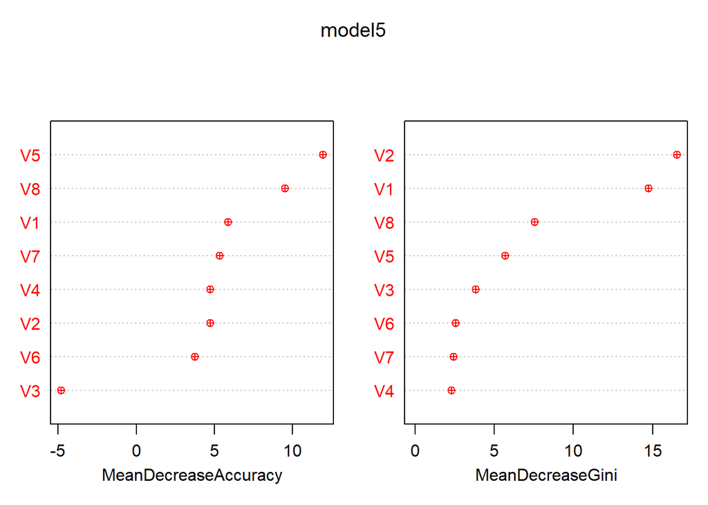

```r
model5 <- randomForest(Outcome ~ V1+V2+V3+V4+V5+V6+V7+V8, data = df.train, mtry = 5, importance = TRUE)
varImpPlot(model5, col = 'red', pch = 10)
```

```r
predictions <- predict(model5, df.train[,-1], type = 'Class', predict.all = TRUE)
predictions_final <- predictions$aggregate
ct <- table(df.train[,1], predictions_final)
ct
```

```
##    predictions_final
##      0  1
##   0 91  0
##   1  0 41
```

```r
accu <- (ct[1,1] + ct[2,2])/(ct[1,2]+ ct[2,1]+ ct[1,1] + ct[2,2])
accu
```

```
## [1] 1
```

```r
precision <- ct[1,1]/(ct[1,1] + ct[1,2])
precision
```

```
## [1] 1
```

```r
recall <- ct[1,1]/(ct[1,1] + ct[2,1])
recall
```

```
## [1] 1
```

```r
f1score <- (2*precision*recall)/(precision+recall)
f1score
```

```
## [1] 1
```

## 3.3 Random Forrest - Predicting on validation dataset

```r
predictions_valid <- predict(model5, df.valid[,-1], type = 'Class', predict.all = TRUE)
predictions_valid_final <- predictions_valid$aggregate
ct <- table(df.valid[,1], predictions_valid_final)
ct
```

```
##    predictions_valid_final
##      0  1
##   0 24  7
##   1  9  5
```

```r
accu <- (ct[1,1] + ct[2,2])/(ct[1,2]+ ct[2,1]+ ct[1,1] + ct[2,2])
accu
```

```
## [1] 0.6444444
```

```r
precision <- ct[1,1]/(ct[1,1] + ct[1,2])
precision
```

```
## [1] 0.7741935
```

```r
recall <- ct[1,1]/(ct[1,1] + ct[2,1])
recall
```

```
## [1] 0.7272727
```

```r
f1score <- (2*precision*recall)/(precision+recall)
f1score
```

```
## [1] 0.75
```

## 3.4 Random Forrest- Predicting on test dataset using the fitted model

```r
predictions_test <- predict(model5, df.testfinal[,-1], type = 'Class', predict.all = TRUE)
predictions_test_final <- predictions_test$aggregate
ct <- table(df.testfinal[,1], predictions_test_final)
ct
```

```
##    predictions_test_final
##     0 1
##   0 7 1
##   1 2 2
```

```r
accu <- (ct[1,1] + ct[2,2])/(ct[1,2]+ ct[2,1]+ ct[1,1] + ct[2,2])
accu
```

```
## [1] 0.75
```

```r
precision <- ct[1,1]/(ct[1,1] + ct[1,2])
precision
```

```
## [1] 0.875
```

```r
recall <- ct[1,1]/(ct[1,1] + ct[2,1])
recall
```

```
## [1] 0.7777778
```

```r
f1score <- (2*precision*recall)/(precision+recall)
f1score
```

```
## [1] 0.8235294
```

We observe an accuracy of 75% on the test dataset with this model.

# 4 Naive Bayes classification model

This model has been used as it is known to work well with categorical data which is a majority in our dataset.

## 4.1 Binning

We first make our continuous variables as categorical by binning them manually instead of relying on the model for it. The binning has been done using the quantiles as the interval.

```r
V9_median <- median(clean.df$V9)
V9_1stquartile <- quantile(clean.df$V9, 0.25)
V9_3rdquartile <- quantile(clean.df$V9, 0.75)
V9_max <- max(clean.df$V9)
V9_min <- min(clean.df$V9)
clean.df$V9bin<- cut(clean.df$V9, breaks=c(V9_min,V9_1stquartile,V9_median,V9_3rdquartile, V9_max), labels=c("1","2","3","4"), include.lowest = TRUE)

V1_median <- median(clean.df$V1)
V1_1stquartile <- quantile(clean.df$V1, 0.25)
V1_3rdquartile <- quantile(clean.df$V1, 0.75)
V1_max <- max(clean.df$V1)
V1_min <- min(clean.df$V1)
clean.df$V1bin<- cut(clean.df$V1, breaks=c(V1_min,V1_1stquartile,V1_median,V1_3rdquartile, V1_max), labels=c("1","2","3","4"), include.lowest = TRUE)

V2_median <- median(clean.df$V2)
V2_1stquartile <- quantile(clean.df$V2, 0.25)
V2_3rdquartile <- quantile(clean.df$V2, 0.75)
V2_max <- max(clean.df$V2)
V2_min <- min(clean.df$V2)
clean.df$V2bin<- cut(clean.df$V2, breaks=c(V2_min,V2_1stquartile,V2_median,V2_3rdquartile, V2_max), labels=c("1","2","3","4"), include.lowest = TRUE)
```

## 4.2 Resplit after Binning

We will have to split the data again into test, train and validation to include those variables with bins

```r
set.seed(100)

clean.df1<-clean.df[clean.df$Outcome == 1,]
clean.df0<-clean.df[clean.df$Outcome == 0,]

train.prop = 0.7 #set 70% for training dataset
train.cases1 = sample(nrow(clean.df1), nrow(clean.df1)*train.prop)
train.cases0 = sample(nrow(clean.df0), nrow(clean.df0)*train.prop)
rm(df.train)
df.train<-rbind(clean.df1[train.cases1,],clean.df0[train.cases0,])

rm(df.hold)
df.hold<-rbind(clean.df1[-train.cases1,],clean.df0[-train.cases0,])

#SPLIT Hold data INTO 80 and 20 for test and Validation

test.prop=.8
df.hold1<-df.hold[df.hold$Outcome == 1,]
df.hold0<-df.hold[df.hold$Outcome == 0,]
test.valid1 = sample(nrow(df.hold1), nrow(df.hold1)*test.prop)
test.valid0 = sample(nrow(df.hold0), nrow(df.hold0)*test.prop)

rm(df.valid)
rm(df.testfinal)
df.valid<-rbind(df.hold1[test.valid1,],df.hold0[test.valid0,])
df.testfinal<-rbind(df.hold1[-test.valid1,],df.hold0[-test.valid0,])
```

## 4.3 Naive Bayes - Initial Model-Training all variables

Now we are going to the model creation part

```r
require(e1071)
Naive_Bayes_Model_2 = naiveBayes(Outcome ~ V1bin+V2bin+V3+V4+V5+V6+V7+V8+V9bin, data=df.train)
Naive_Bayes_Model_2
```

```
##
## Naive Bayes Classifier for Discrete Predictors
##
## Call:
## naiveBayes.default(x = X, y = Y, laplace = laplace)
##
## A-priori probabilities:
## Y
##         0         1
## 0.6893939 0.3106061
##
## Conditional probabilities:
##    V1bin
## Y           1         2         3         4
##   0 0.2747253 0.2527473 0.1758242 0.2967033
##   1 0.2682927 0.3658537 0.2439024 0.1219512
##
##    V2bin
## Y           1         2         3         4
##   0 0.2307692 0.2417582 0.2527473 0.2747253
##   1 0.4634146 0.1219512 0.2195122 0.1951220
##
##    V3
## Y           0         1         2
##   0 0.5494505 0.1318681 0.3186813
##   1 0.3658537 0.1951220 0.4390244
##
##    V4
## Y           0         1
##   0 0.6483516 0.3516484
##   1 0.5121951 0.4878049
##
##    V5
## Y            0          1          2          3
##   0 0.91208791 0.04395604 0.03296703 0.01098901
##   1 0.73170732 0.24390244 0.02439024 0.00000000
##
##    V6
## Y            0          1
##   0 0.95604396 0.04395604
##   1 0.82926829 0.17073171
##
##    V7
## Y           0         1
##   0 0.8901099 0.1098901
##   1 0.8048780 0.1951220
##
##    V8
## Y            0          1          2          3          4          6
##   0 0.51648352 0.25274725 0.17582418 0.01098901 0.03296703 0.01098901
##   1 0.56097561 0.24390244 0.09756098 0.09756098 0.00000000 0.00000000
##
##    V9bin
## Y           1         2         3         4
##   0 0.0000000 0.2637363 0.4175824 0.3186813
##   1 0.8048780 0.1951220 0.0000000 0.0000000
```

```r
pred_train_naive <- predict(Naive_Bayes_Model_2, df.train[,-1], type = "class")
ct <- table(df.train[,1], pred_train_naive)
ct
```

```
##    pred_train_naive
##      0  1
##   0 90  1
##   1  3 38
```

```r
accu <- (ct[1,1] + ct[2,2])/(ct[1,2]+ ct[2,1]+ ct[1,1] + ct[2,2])
accu
```

```
## [1] 0.969697
```

```r
precision <- ct[1,1]/(ct[1,1] + ct[1,2])
precision
```

```
## [1] 0.989011
```

```r
recall <- ct[1,1]/(ct[1,1] + ct[2,1])
recall
```

```
## [1] 0.9677419
```

```r
f1score <- (2*precision*recall)/(precision+recall)
f1score
```

```
## [1] 0.9782609
```

## 4.4 Predicting on validation dataset using the naive bayes fitted model

```r
pred_valid_naive <- predict(Naive_Bayes_Model_2, df.valid[,-1], type = "class")
ct <- table(df.valid[,1], pred_valid_naive)
ct
```

```
##    pred_valid_naive
##      0  1
##   0 27  4
##   1  2 12
```

```r
accu <- (ct[1,1] + ct[2,2])/(ct[1,2]+ ct[2,1]+ ct[1,1] + ct[2,2])
accu
```

```
## [1] 0.8666667
```

```r
precision <- ct[1,1]/(ct[1,1] + ct[1,2])
precision
```

```
## [1] 0.8709677
```

```r
recall <- ct[1,1]/(ct[1,1] + ct[2,1])
recall
```

```
## [1] 0.9310345
```

```r
f1score <- (2*precision*recall)/(precision+recall)
f1score
```

```
## [1] 0.9
```

Accuracy for the Naive Bayes model on the validation dataset went down to 86.67% and the values for precision, recall and F-1 score were 87.10%, 93.10% and 90% respectively.

## 4.5 Naive Bayes Without V9- Prediction on Training Data

Now we will make a model by excluding variable V9 based on our EDA and logistic model’s results

```r
Naive_Bayes_Model = naiveBayes(Outcome ~ V1bin+V2bin+V3+V4+V5+V6+V7+V8, data=df.train)
Naive_Bayes_Model
```

```
##
## Naive Bayes Classifier for Discrete Predictors
##
## Call:
## naiveBayes.default(x = X, y = Y, laplace = laplace)
##
## A-priori probabilities:
## Y
##         0         1
## 0.6893939 0.3106061
##
## Conditional probabilities:
##    V1bin
## Y           1         2         3         4
##   0 0.2747253 0.2527473 0.1758242 0.2967033
##   1 0.2682927 0.3658537 0.2439024 0.1219512
##
##    V2bin
## Y           1         2         3         4
##   0 0.2307692 0.2417582 0.2527473 0.2747253
##   1 0.4634146 0.1219512 0.2195122 0.1951220
##
##    V3
## Y           0         1         2
##   0 0.5494505 0.1318681 0.3186813
##   1 0.3658537 0.1951220 0.4390244
##
##    V4
## Y           0         1
##   0 0.6483516 0.3516484
##   1 0.5121951 0.4878049
##
##    V5
## Y            0          1          2          3
##   0 0.91208791 0.04395604 0.03296703 0.01098901
##   1 0.73170732 0.24390244 0.02439024 0.00000000
##
##    V6
## Y            0          1
##   0 0.95604396 0.04395604
##   1 0.82926829 0.17073171
##
##    V7
## Y           0         1
##   0 0.8901099 0.1098901
##   1 0.8048780 0.1951220
##
##    V8
## Y            0          1          2          3          4          6
##   0 0.51648352 0.25274725 0.17582418 0.01098901 0.03296703 0.01098901
##   1 0.56097561 0.24390244 0.09756098 0.09756098 0.00000000 0.00000000
```

```r
pred_train_naive_noV9 <- predict(Naive_Bayes_Model, df.train[,-1], type = "class")
ct <- table(df.train[,1], pred_train_naive_noV9)
ct
```

```
##    pred_train_naive_noV9
##      0  1
##   0 83  8
##   1 20 21
```

```r
accu <- (ct[1,1] + ct[2,2])/(ct[1,2]+ ct[2,1]+ ct[1,1] + ct[2,2])
accu
```

```
## [1] 0.7878788
```

```r
precision <- ct[1,1]/(ct[1,1] + ct[1,2])
precision
```

```
## [1] 0.9120879
```

```r
recall <- ct[1,1]/(ct[1,1] + ct[2,1])
recall
```

```
## [1] 0.8058252
```

```r
f1score <- (2*precision*recall)/(precision+recall)
f1score
```

```
## [1] 0.8556701
```

## 4.6 Naive Bayes Predicting on validation dataset

```r
pred_valid_naive_noV9 <- predict(Naive_Bayes_Model, df.valid[,-1], type = "class")
ct <- table(df.valid[,1], pred_valid_naive_noV9)
ct
```

```
##    pred_valid_naive_noV9
##      0  1
##   0 25  6
##   1 10  4
```

```r
accu <- (ct[1,1] + ct[2,2])/(ct[1,2]+ ct[2,1]+ ct[1,1] + ct[2,2])
accu
```

```
## [1] 0.6444444
```

```r
precision <- ct[1,1]/(ct[1,1] + ct[1,2])
precision
```

```
## [1] 0.8064516
```

```r
recall <- ct[1,1]/(ct[1,1] + ct[2,1])
recall
```

```
## [1] 0.7142857
```

```r
f1score <- (2*precision*recall)/(precision+recall)
f1score
```

```
## [1] 0.7575758
```

## 4.7 Naive Bayes Predicting on test dataset using the newly fitted model

```r
pred_test_naive_noV9 <- predict(Naive_Bayes_Model, df.testfinal[,-1], type = "class")
ct <- table(df.testfinal[,1], pred_test_naive_noV9)
ct
```

```
##    pred_test_naive_noV9
##     0 1
##   0 8 0
##   1 2 2
```

```r
accu <- (ct[1,1] + ct[2,2])/(ct[1,2]+ ct[2,1]+ ct[1,1] + ct[2,2])
accu
```

```
## [1] 0.8333333
```

```r
precision <- ct[1,1]/(ct[1,1] + ct[1,2])
precision
```

```
## [1] 1
```

```r
recall <- ct[1,1]/(ct[1,1] + ct[2,1])
recall
```

```
## [1] 0.8
```

```r
f1score <- (2*precision*recall)/(precision+recall)
f1score
```

```
## [1] 0.8888889
```

Using the fitted model we observe that the accuracy for the Naive Bayes is 83.33% on the test dataset. We also observe a 100% precision for this model.

# 5 Summary